# VegVault database

## Traits

Functional traits of vegetation taxa follow the same structure of `Dataset` and `Samples` obtained directly from *Dataset Source-types*.

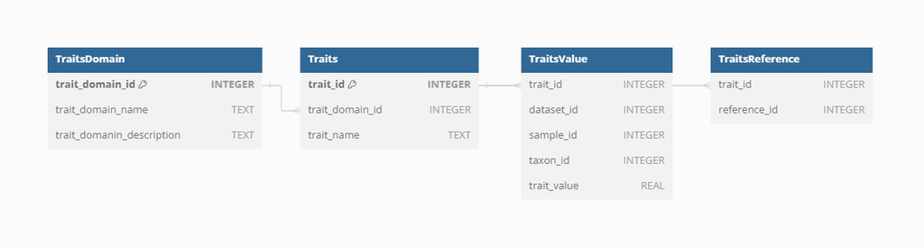

### Trait domain

As there are many varying names for the same “traits”, the **VegVault** database contains *Trait Domain* information to group traits together.

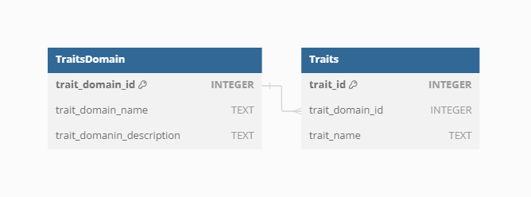

There are currently 6 trait domains following the [Diaz et al. (2016)](https://www.nature.com/articles/nature16489)

| Trait domain |
| --- |
| Stem specific density |
| Leaf nitrogen content per unit mass |
| Diaspore mass |
| Plant heigh |
| Leaf Area |
| Leaf mass per area |

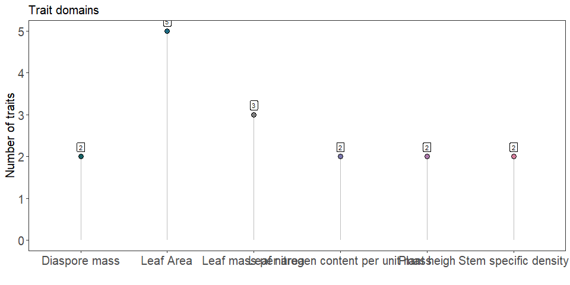

### Trait Values

To store a trait value, information needs to be linked among `Dataset`, `Sample`, `Taxa`, and `Trait`.

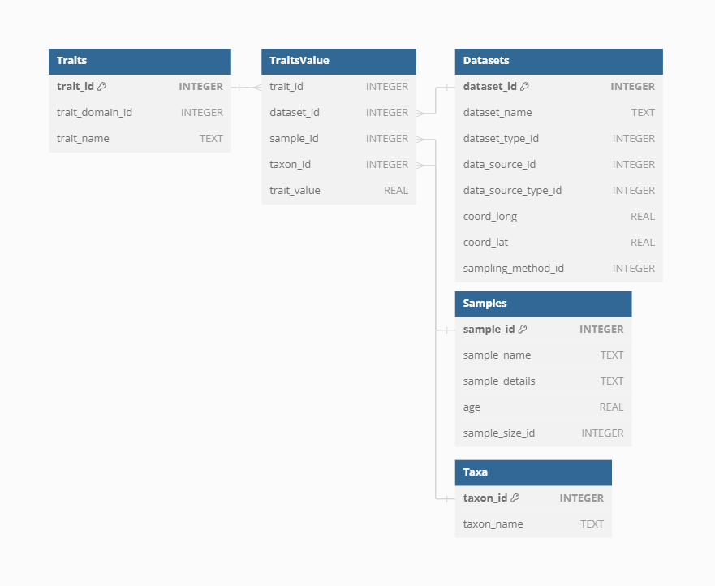

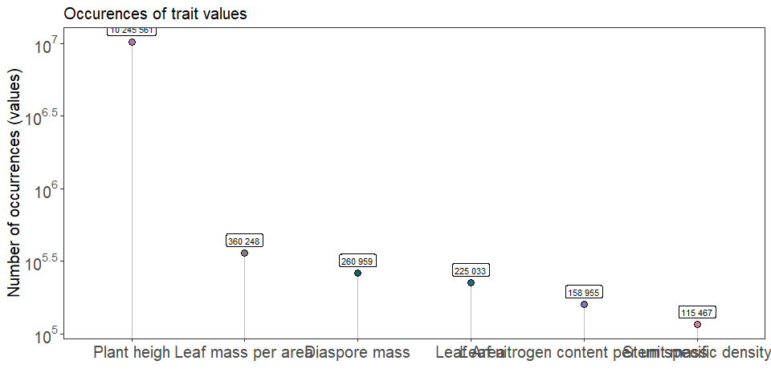

### Trait reference

For full clarity, on top of `Dataset` and `Sample`, each `Trait` can have additional references.

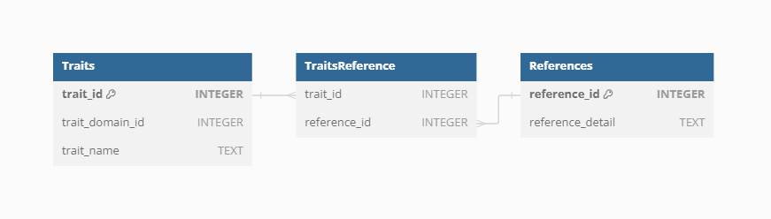

## Abiotic data

Abiotic data is aimed to provide information about all relevant abiotic information affecting vegetation distribution and its traits.

Abiotic data is linked to the structure of the **VegVault** Database by the `gridpoints`, which are artificially created points to *reasonably* cover the resolution of both modern and past data for vegetation and abiotic data.

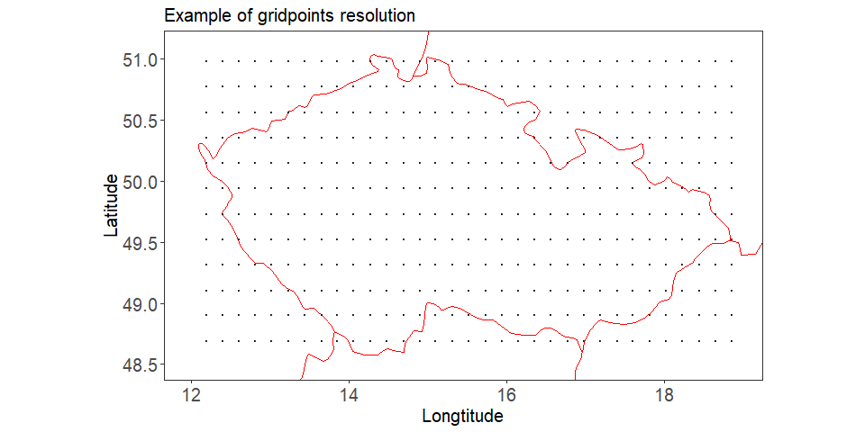

There are currently abiotic from [CHELSA](https://chelsa-climate.org/) and [CHELSA-TRACE21](https://chelsa-climate.org/chelsa-trace21k/) and [WoSIS](https://www.isric.org/explore/wosis). CHELSA and CHELSA-TRACE21 are built on the same structure of variables (visit the websites for more info).

| Variable name | Variable unit | source of data |
| --- | --- | --- |
| bio1 | °C | CHELSA |
| bio4 | °C | CHELSA |
| bio6 | °C | CHELSA |
| bio12 | kg m-2 year-1 | CHELSA |
| bio15 | Unitless | CHELSA |
| bio18 | kg m-2 quarter-1 | CHELSA |
| bio19 | kg m-2 quarter-1 | CHELSA |
| HWSD2 | Unitless | WoSIS-SoilGrids |

Abiotic data is simply linked to `Samples`.

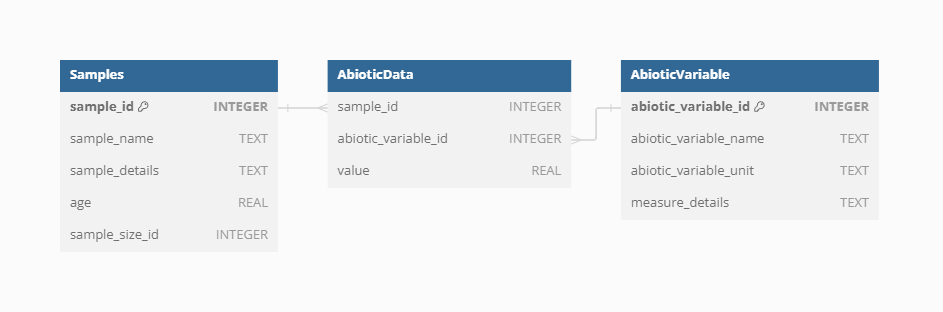

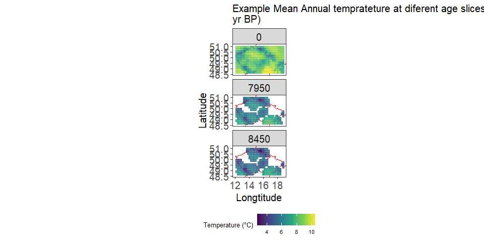

Note that the spatial resolution is higher for modern climate data than for the past. This is to reduce the size of the past climate data.

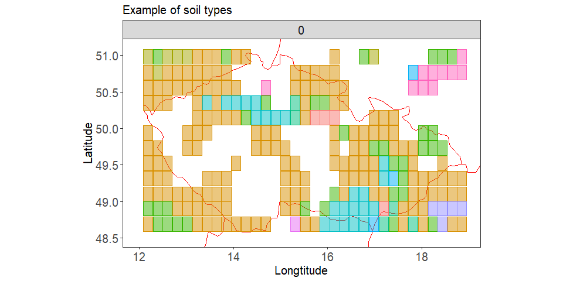

# Section III: Assembly details of VegVault 1.0.0

The **VegVault** version **1.0.0** has been assembled from other publicly available databases.

## Assembly process

Here is a general visualisation of the assembly process:

[figure not shown]

**Figure legend**:

1. **[Neotoma Paleoecology Database](https://www.neotomadb.org/)** - open, community-curated data and services for paleoecological and paleoenvironmental data
   - source of fossil pollen data
2. **[sPlotOpen](https://idiv-biodiversity.de/en/splot/splotopen.html)** - The open-access version of sPlot
   - source of current vegetation plot data
3. **[Botanical Information and Ecology Network](https://bien.nceas.ucsb.edu/bien/)** - global patterns of plot inventories and surveys
   - source of current vegetation plot and vegetation trait data
4. **[TRY Plant Trait Database](https://www.try-db.org/TryWeb/Home.php)** - open access plant trait data
   - source of vegetation trait data
5. **[Climatologies at High resolution for the Earth’s Land Surface Area](https://chelsa-climate.org/)** - Long-term, transient modern- and paleo-climate data
   - source of abiotic data
6. **[World Soil Information Service](https://www.isric.org/explore/wosis)** - harmonised soil profile database
   - source of abiotic data
7. **[FOSSILPOL](https://hope-uib-bio.github.io/FOSSILPOL-website/)** - The workflow that aims to process and standardise global palaeoecological pollen data for macroecological studies
   - a method to obtain and process fossil pollen data
8. **[RBIEN R package](https://github.com/bmaitner/RBIEN)** - Tools for accessing the BIEN database
   - a method to obtain current vegetation plot data
9. **[VegVault-FOSSILPOL GitHub repo](https://github.com/OndrejMottl/VegVault-FOSSILPOL/tree/v1.0.0)**
   - a Tag (v1.0.0) to obtain and process fossil pollen data
10. **[VegVault-Vegetation_data GitHub repo](https://github.com/OndrejMottl/VegVault-Vegetation_data/tree/v1.0.0)**
    - a Tag (v1.0.0) to process current vegetation plot data
11. **[VegVault-Trait_data GitHub repo](https://github.com/OndrejMottl/VegVault-Trait_data/tree/v1.1.0)**
    - a Tag (v1.1.0) to process vegetation trait data
12. **[VegVault-abiotic_data GitHub repo](https://github.com/OndrejMottl/VegVault-abiotic_data/tree/v1.1.0)**
    - a Tag (v1.1.0) to process abiotic data
13. **[VegVault GitHub repo](https://github.com/OndrejMottl/VegVault)**
    - a Tag (v1.0.0) to transfer the data into the SQLite database
14. **VegVault** - SQLite database (v1.0.0)

### Note on GitHub Tags

*…Tags are ref’s that point to specific points in Git history. Tagging is generally used to capture a point in history…*

Here, the Tags have been used to ensure reproducibility of this version of **VegVault**. GitHub repo can change but the specific Tag used here (and also used in the code to source the data) ensure the transparency of the state of the database.

# Section IV: Examples of usage

The **VegVault** database can be accessed via our newly developed [{vaultkeepr} R-package](https://github.com/OndrejMottl/vaultkeepr), which provides a series of easy-to-use functions in R programming language.

The {vaultkeepr} can be installed from [GitHub](https://github.com/) with:

```r
# install.packages("remotes")
remotes::install_github("OndrejMottl/vaultkeepr")
```

and then all functions will be made available by attaching as:

```r
library(vaultkeepr)
```

## Example 1

In the first example, we can imagine a scenario, where we are interested in spatiotemporal patterns of the *Picea* genus across North America for modern data and since the Last Glacial Maximum. Obtaining such data is straightforward:

```r
# First create a plan
plan_na_plots_picea <-
  # Access the VegVault
  vaultkeepr::open_vault(
    path = paste0(
      data_storage_path,
      "Data/VegVault/VegVault.sqlite"
    )
  ) %>%
  # Start by adding dataset information
  vaultkeepr::get_datasets() %>%
  # Select both modern and paleo plot data
  vaultkeepr::select_dataset_by_type(
    sel_dataset_type = c(
      "vegetation_plot",
      "fossil_pollen_archive"
    )
  ) %>%
  # Limit data to North America
  vaultkeepr::select_dataset_by_geo(
    lat_lim = c(22, 60),
    long_lim = c(-135, -60)
  ) %>%
  # Add samples
  vaultkeepr::get_samples() %>%
  # Limit the samples by age
  vaultkeepr::select_samples_by_age(
    age_lim = c(0, 15e3)
  ) %>%
  # Add taxa
  vaultkeepr::get_taxa(
    # Classify all data to a genus level
    classify_to = "genus"
  ) %>%
  # Extract only Picea data
  vaultkeepr::select_taxa_by_name(sel_taxa = c("Picea"))

# Execute the plan
data_na_plots_picea <-
  vaultkeepr::extract_data(plan_na_plots_picea)
```

Now, we plot the presence of *Picea* in each 2500-year bin.

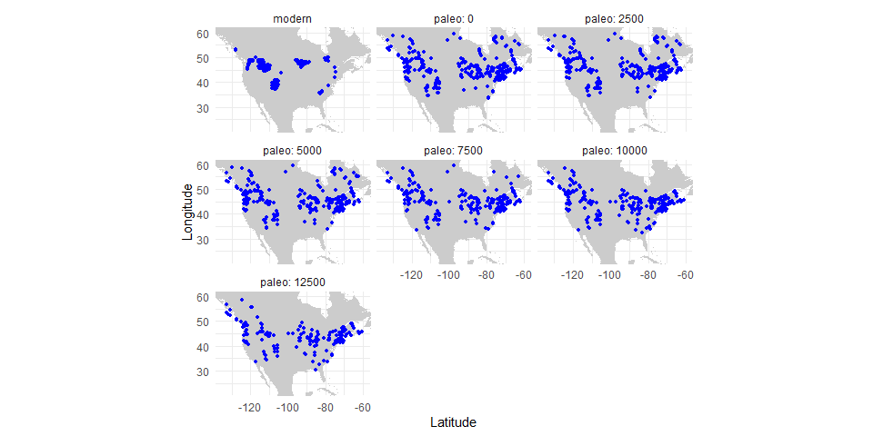

## Example 2

In the second example, let’s imagine we want to do Species Distribution Modeling for all plant taxa in the Czech Republic. We will extract modern plot-based data and Mean Annual temprature.

```r
# Again start by creating a plan
plan_cz_modern <-
  # Acess the VegVault file
  vaultkeepr::open_vault(
    path = paste0(
      data_storage_path,
      "Data/VegVault/VegVault.sqlite"
    )
  ) %>%
  # Add the dataset information
  vaultkeepr::get_datasets() %>%
  # Select modern plot data and climate
  vaultkeepr::select_dataset_by_type(
    sel_dataset_type = c(
      "vegetation_plot",
      "gridpoints"
    )
  ) %>%
  # Limit data to Czech Republic
  vaultkeepr::select_dataset_by_geo(
    lat_lim = c(48.5, 51.1),
    long_lim = c(12, 18.9)
  ) %>%
  # Add samples
  vaultkeepr::get_samples() %>%
  # select only modern data
  vaultkeepr::select_samples_by_age(
    age_lim = c(0, 0)
  ) %>%
  # Add abiotic data
  vaultkeepr::get_abiotic() %>%
  # Select only Mean Anual Temperature (bio1)
  vaultkeepr::select_abiotic_var_by_name(
    sel_var_name = "bio1"
  ) %>%
  # add taxa
  vaultkeepr::get_taxa()

# Execute the plan
data_cz_modern <-
  vaultkeepr::extract_data(plan_cz_modern)
```

Now we can simply plot both the climatic data and the plot vegetation data:

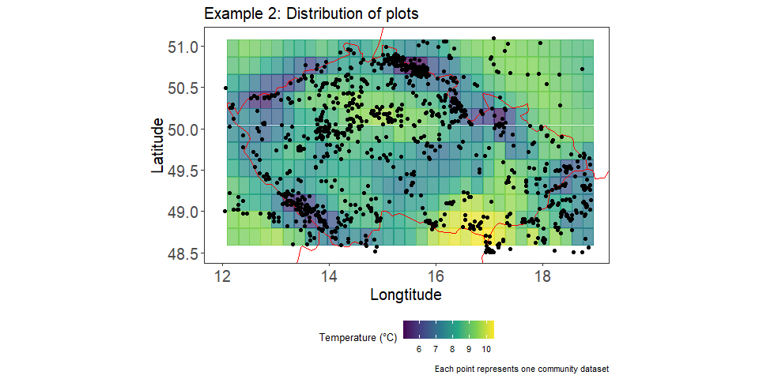

## Example 3

In the last example, let’s imagine we want to reconstruct the Community Weighted Mean (CWM) of plant height for Latin America between 6-12 ka yr BP.

```r
# Again start by creating a plan
plan_la_traits <-
  # Acess the VegVault file
  vaultkeepr::open_vault(
    path = paste0(
      data_storage_path,
      "Data/VegVault/VegVault.sqlite"
    )
  ) %>%
  # Add the dataset information
  vaultkeepr::get_datasets() %>%
  # Select modern plot data and climate
  vaultkeepr::select_dataset_by_type(
    sel_dataset_type = c(
      "fossil_pollen_archive",
      "traits"
    )
  ) %>%
  # Limit data to Latin America
  vaultkeepr::select_dataset_by_geo(
    lat_lim = c(-53, 28),
    long_lim = c(-110, -38),
    sel_dataset_type = c(
      "fossil_pollen_archive",
      "traits"
    )
  ) %>%
  # Add samples
  vaultkeepr::get_samples() %>%
  # Limit to 6-12 ka yr BP
  vaultkeepr::select_samples_by_age(
    age_lim = c(6e3, 12e3)
  ) %>%
  # add taxa
  vaultkeepr::get_taxa(
    # Clasify all data to a genus level
    classify_to = "genus"
  ) %>%
  # add trait information
  vaultkeepr::get_traits(
    # Clasify all data to a genus level
    classify_to = "genus"
  ) %>%
  # Only select the plant height
  vaultkeepr::select_traits_by_domain_name(
    sel_domain = "Plant heigh"
  )

# Execute the plan
data_la_traits <-
  vaultkeepr::extract_data(plan_la_traits)
```

Now let’s plot the overview of the data

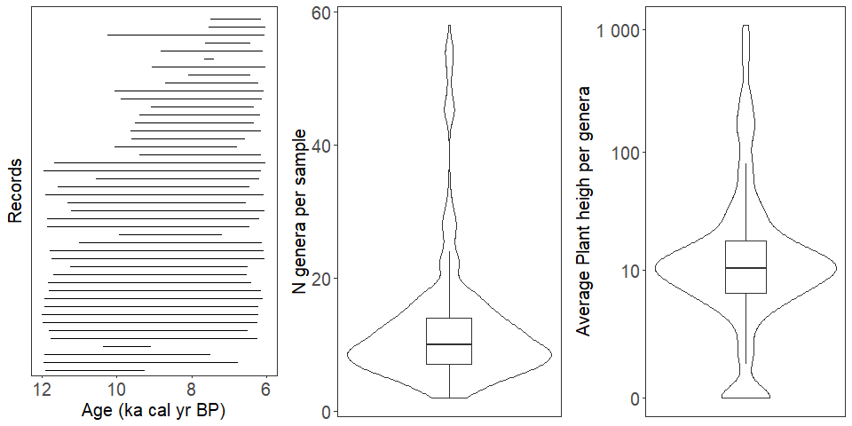

# Section V: Outlook and future directions